# regression_2

1. Practice Predicting NBA Salary. Download the data at: https://bryantstats.github.io/math460/python/nba_salary.csv

Import the data and drop all the missing values

Set the input (X) and output (y) (Use df.columns to see all the columns to easier copy/paste). Split the data into 60% training and 40% testing (No need to do 1.3 and 1.4 as all variables are numeric and have correct types)

Train a random forest of 200 trees and consider only 2 variables at each split for the trees. What is testing Rsquared of the model?

What is the most important variable according to the model?

Find a random forest that have a higher testing Rsquared than the first forest.

1. Import the data and drop all the missing values

```python
# Importing libraries
import pandas as pd
import numpy as np
from sklearn import tree
from sklearn import metrics
```

```python
# Importing data and saving it to a dataframe; the first five rows are displayed with the head function.
df = pd.read_csv('nba_salary.csv')
df.columns
```

```
Index(['Salary', 'NBA_DraftNumber', 'Age', 'G', 'MP', 'PER', 'TS%', '3PAr',
       'FTr', 'ORB%', 'DRB%', 'TRB%', 'AST%', 'STL%', 'BLK%', 'TOV%', 'USG%',
       'OWS', 'DWS', 'WS', 'WS/48', 'OBPM', 'DBPM', 'BPM', 'VORP'],
      dtype='object')
```

1. Set the input (X) and output (y) (Use df.columns to see all the columns to easier copy/paste). Split the data into 60% training and 40% testing (No need to do 1.3 and 1.4 as all variables are numeric and have correct types)2.

```python
np.random.seed(42)

X = df.loc[:,[ 'Age', 'G', 'MP', 'PER']]

# Assign target variable
y = df['Salary']

# Setting Input / Output and partitioning data with a 40:60 testing:training split.
from sklearn.model_selection import train_test_split
np.random.seed(42)

x_train,x_test,y_train,y_test=train_test_split(X,y,test_size=0.40)
```

1. Train a random forest of 200 trees and consider only 2 variables at each split for the trees. What is testing Rsquared of the model?

```python
# Create a decision tree and train. The R-Sqared of this model on the testing data is ~0.4578.
np.random.seed(42)
from sklearn.tree import DecisionTreeRegressor

forest1 = DecisionTreeRegressor(criterion='squared_error', max_leaf_nodes=2)
forest1.fit(x_train, y_train)

from sklearn.ensemble import RandomForestRegressor
r1 = RandomForestRegressor(n_estimators=100, max_features=2)
r1.fit(x_train, y_train)

# Rsquared
from sklearn.metrics import r2_score
print('Rsquared on Testing: ', r2_score(y_test, r1.predict(x_test)))
```

```
Rsquared on Testing:  0.4578120831741852
```

The testing R-Squared of the model is 0.4578.

1. What is the most important variable according to the model?

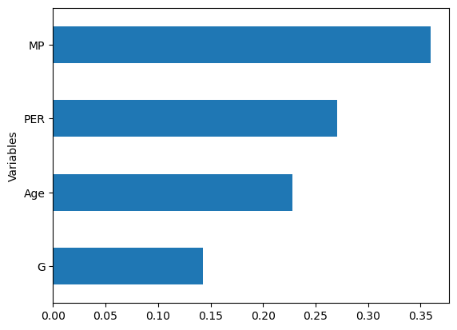

```python
# Plotting the variable importance from the forest created above.
import warnings
warnings.filterwarnings('ignore')

sorted_idx = (-r1.feature_importances_).argsort()

feature_importance = pd.DataFrame({'Variables':x_train.columns[sorted_idx], 'Importance':r1.feature_importances_[sorted_idx]})
df = feature_importance[:10]
df.sort_values('Importance',inplace=True)

df.plot(kind='barh',y='Importance',x='Variables', legend=False)
```

According to the variable importance plot above, The variable `MP` (Minutes Played) is the most important. This makes sense since teams typically pay their star players, (who typically play the most minutes), the most amount of money.

1. Find a random forest that have a higher testing Rsquared than the first forest.

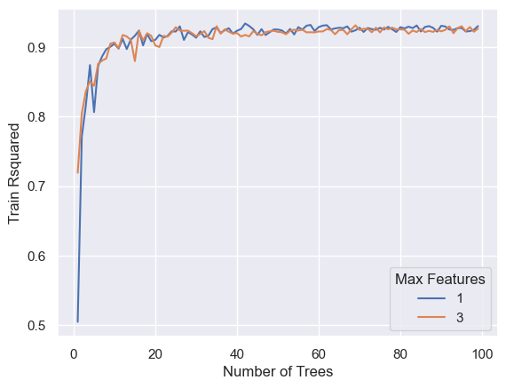

```python
n1 = 1
n2 = 100
l1 = 1
l2 = 3

ac = pd.DataFrame([], columns=list(['Number of Trees','Max Features','Train Rsquared']))

for rs in range(n1, n2):
    for lr in [l1, l2]:
        boost = RandomForestRegressor(n_estimators=rs, max_features=lr)
        boost.fit(x_train,y_train)

        ac = pd.concat([ac, pd.DataFrame([[rs, lr, boost.score(x_train, y_train)]],
                                    columns=list(['Number of Trees','Max Features','Train Rsquared']))],
                       ignore_index=True)


import seaborn as sns; sns.set()
import matplotlib.pyplot as plt
ax = sns.lineplot(x="Number of Trees", y="Train Rsquared", hue =ac['Max Features'].astype('category'),data=ac)
```

```python
np.random.seed(42)

forest2 = RandomForestRegressor(criterion='squared_error', n_estimators=20, max_features=3)
forest2.fit(x_train, y_train)

from sklearn.ensemble import RandomForestRegressor
r1 = RandomForestRegressor(n_estimators=20, max_features=3)
r1.fit(x_train, y_train)

# Rsquared
from sklearn.metrics import r2_score
print('Rsquared on Testing: ', r2_score(y_test, r1.predict(x_test)))
```

```
Rsquared on Testing:  0.4792732924899903
```

The second Forest had a has a slightly higher R-Squared statistic on testing at ~0.4793.